[figure not shown]

[OHI Science](http://ohi-science.org) | [Citation policy](http://ohi-science.org/citation-policy/)

# OHI 2016: Sea Level Rise Pressure Layer

Compiled on Mon Mar 20 15:58:58 2017 by jstewart

**Note**: this is an archived prep file from the Ocean Health Index. The original is located [here](https://github.com/OHI-Science/ohiprep/tree/7aa6f3b5e1b001bb86188788e0b83bc31bb79140/globalprep/prs_slr/v2016).

# Summary

There are two parts to creating this layer:

1. Data prep to get raw data into the correct format:
   - If necessary, read .nc.gz files from aviso: ftp://ftp.aviso.altimetry.fr/global/delayed-time/grids/climatology/monthly_mean/
   - unzip .gz files and then delete .gz
   - Read monthly mean sea level data as rasters
2. Creating the pressure layers for OHI Global:
   - Clip all monthly rasters to the coast using a 3 nautical mile offshore buffer
   - Calculate annual mean sea level anomaly rasters from monthly data
   - Determine a reference point as the 99.99th quantile of the data across all years (1993 - 2015)
   - Rescale values from 0 to 1 using the reference point
   - Set to zero all negative values, indicating decreases in mean sea level
   - Resample raster to ~ 1km2 and reproject to Molleweide

This process is completed entirely within this script.

# Data

The raw data are monthly mean sea level anomalies, in meters. The anomalies are calculated using a reference period of 1993 - 2012. The anomalies represent a cumulative anomaly rather than an instantaneous anomaly.

**Reference**: The altimeter products were produced and distributed by Aviso (http://www.aviso.altimetry.fr/), as part of the Ssalto ground processing segment. [AVISO MSLA heights, monthly means](http://www.aviso.altimetry.fr/en/data/products/sea-surface-height-products/global/msla-mean-climatology.html)

**Downloaded**: March 18, 2016  
**Description**: Monthly mean sea level anomaly (meters above mean sea level)  
**Native data resolution**: 0.25 degree grid cells  
**Time range**: January 1993 - December 2015  
**Format**: NetCDF

# Methods

## Setup

```r
knitr::opts_chunk$set(fig.width = 6, fig.height = 4, fig.path = 'figs/',message = FALSE, warning = FALSE)

#setting up provenance
# devtools::install_github('oharac/provRmd')
# library(provRmd)
# prov_setup()

library(sp)        # the classes and methods that make up spatial ops in R
library(rgdal)
library(raster)
library(tmap)
library(rasterVis)
library(lattice)
library(ggplot2)
library(ncdf4)
library(RColorBrewer)
library(doParallel)
library(foreach)
library(parallel)
library(maptools)
data(wrld_simpl)


dir_git <- '~/github/ohiprep'

source('~/github/ohiprep/src/R/common.R')

dir_anx <- file.path(dir_M, 'git-annex/globalprep')

dir_anx_aviso <- file.path(dir_M, 'git-annex/globalprep/_raw_data/AVISO_slr/d2016')

### set up proj4string options: WGS84
p4s_wgs84 <- '+proj=longlat +datum=WGS84 +no_defs +ellps=WGS84 +towgs84=0,0,0'

### Define spectral color scheme for plotting maps
cols      = rev(colorRampPalette(brewer.pal(9, 'Spectral'))(255)) # rainbow color scheme

# define mollweide projection

mollCRS <- CRS('+proj=moll')

# Read in ocean raster with cells at 1km. Use this as a template for resampling

ocean = raster(file.path(dir_M,'git-annex/globalprep/spatial/ocean.tif'))
```

## Data Prep

### Download files

```r
reload <- FALSE

if(reload) {
  ### Get filenames from AVISO FTP URL:
  library(RCurl)
  url <- "ftp://ftp.aviso.altimetry.fr/global/delayed-time/grids/climatology/monthly_mean/"
  userpwd <- "ucsb_afflerbach:sioped54j"
  filenames <- getURL(url,
                      userpwd = userpwd,
                      ftp.use.epsv = FALSE,
                      dirlistonly = TRUE) %>%
    str_split('\n') %>%
    unlist()

  filenames <- filenames[!str_detect(filenames, '.png')] %>%
    sort()


  ### Set up loop to download each file and save to git-annex:

  ftp_dir <- 'ftp://ucsb_afflerbach:sioped54j@ftp.aviso.altimetry.fr/global/delayed-time/grids/climatology/monthly_mean'
  for (i in 1:length(filenames)) { # nc_file <- filenames[2]
    print(i)
    nc_file <- filenames[i]

    download.file(url      = file.path(ftp_dir, nc_file),
                  destfile = file.path(dir_anx_aviso, 'msla_monthly_mean', nc_file),
                  mode     = 'wb')
  }

  zipfiles <- list.files(file.path(dir_anx_aviso, 'msla_monthly_mean'),
                         full.names = TRUE)
  zipfiles <- zipfiles[str_detect(zipfiles, '.gz')]
  for (zipfile in zipfiles) { # zipfile <- zipfiles[1]
    message('Unzipping file: ', zipfile)
    R.utils::gunzip(zipfile, remove = TRUE, skip = TRUE)
  }
}
```

### Clip data to coastal cells

```r
#list all netCDF files
nc_files <- list.files(file.path(dir_anx_aviso, 'msla_monthly_mean'),
                       full.names = TRUE,pattern='.nc')

## resampling raw data to smaller cell size, then create a raster of all coastal cells. The resampling needs to be done
## first to ensure we get the small islands that would otherwise be ignored at larger cell seizes

#offshore 3 nm polygon for all regions
three_nm <- readOGR(dsn= file.path(dir_anx,'spatial/d2014/data'),layer = 'regions_offshore3nm_gcs')

    r <- raster(nc_files[1])%>%
            rotate()%>%
            disaggregate(fact = 8)

    #define projection of the raster before reprojecting
    projection(r) <- "+proj=longlat +datum=WGS84 +ellps=WGS84 +towgs84=0,0,0"

    r_3nm_mask <- mask(r,three_nm, progress='text')
    writeRaster(r_3nm_mask,filename = file.path(dir_git,'globalprep/prs_slr/v2016/int/rast_3nm_mask.tif'))
```

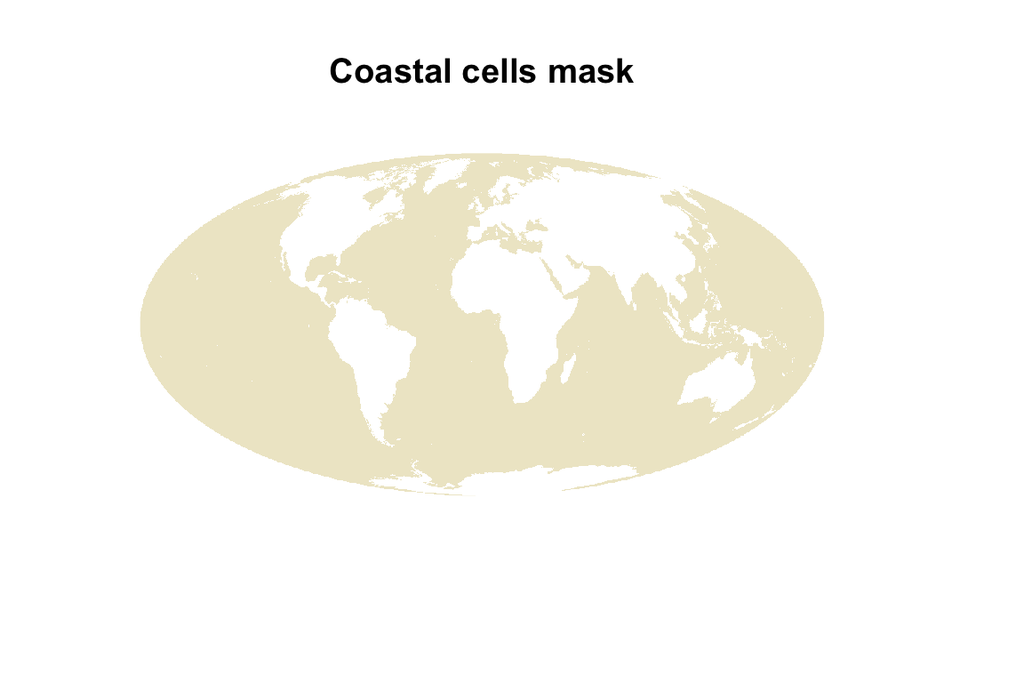

```r
s <- raster(file.path(dir_git,'globalprep/prs_slr/v2016/int/rast_3nm_mask.tif'))
plot(ocean, col='cornsilk2', axes=F, box=F, main = 'Coastal cells mask', legend=F)
plot(s,col='black',axes=F, box=F,legend=F,add=T)
```

`months_coast` is a function that applies the coastal cell mask to the raw data and saves the output.

```r
## Function that rotates each monthly file, sets the long/lat projection, and keeps only coastal cells - saved to GitHub

months_coast <- function(x){

  m_yr <- substr(x,108,115)

  #read in month raster
   r <- raster(x)%>%
          rotate()%>%
        disaggregate(fact = 8)

  #define projection of the raster before reprojecting
  projection(r) <- "+proj=longlat +datum=WGS84 +ellps=WGS84 +towgs84=0,0,0"

  r_mask <- mask(r,r_3nm_mask,progress='text')


  writeRaster(r_mask,filename=paste0(dir_git,'/globalprep/prs_slr/v2016/int/msla_monthly_coast/msla_monthly_coast_',m_yr,'.tif'),overwrite=T)

}

#apply the clipping function to all files
mclapply(nc_files,months_coast,mc.cores=6)
```

## Annual mean sea level anomalies

Annual mean sea level anomaly rasters are derived from the monthly data.

```r
month_files <- list.files(file.path(dir_git,'globalprep/prs_slr/v2016/int/msla_monthly_coast'),full.names=T)

all_yrs <- c(1993:2015)

registerDoParallel(6)

foreach (j = all_yrs) %dopar% {

  msla_yr <- month_files[str_detect(month_files, as.character(j))]

  message('Generating annual MSLA raster for ', j)

  ### stack all rasters for this year, and calc annual mean, then write as raster
  rast_annual_mean <- stack(msla_yr)%>%
                      calc(mean,na.rm=T)%>%
                      writeRaster(filename = paste0(file.path(dir_git),'/globalprep/prs_slr/v2016/int/msla_annual_mean/rast_msla_annual_',j,'.tif'),overwrite=T)

}
```

## Reference Point

The reference point is the 99.99th quantile of the entire data distribution from 1993 - 2015.

```r
annual_means <- list.files(file.path(dir_git,'globalprep/prs_slr/v2016/int/msla_annual_mean'),pattern = '*.tif',full.names=T)

#get data across all years
vals <- c()

for(i in 1993:2015){
  print(i)
  m <- annual_means[which(substr(annual_means,96,99) == i)]%>%
    raster()%>%
    getValues()

  vals <- c(vals,m)

}
```

I want to compare the reference point if we only use positive values or all data values.

```r
vals <- vals[!is.na(vals)]

ref <- quantile(vals,prob = 0.9999,na.rm=T)
#0.246225

#set negative values to 0 before taking ref point
vals_pos = vals[vals >=0]

ref_pos <- quantile(vals_pos,prob=0.9999,na.rm=T)
#0.2523
```

Since the reference point is very similar between these two options, I’m going to use the reference point across all values, not only positive.

## Rescale

Each annual raster is recaled from 0 to 1 using the reference point. If a value is greater than the reference point, it is automatically given a value of 1.

```r
resc_slr <- function(file){

  yr <- substr(file, 96,99)
    raster(file)%>%
      calc(fun=function(x){ifelse(x<0,0,x)})%>% #set all negative values to 0
      calc(fun=function(x){ifelse(x>ref,1,x/ref)})%>%
      projectRaster(crs = mollCRS,over=T)%>%
      resample(ocean,method = 'ngb', filename = paste0(file.path(dir_anx),'/prs_slr/v2016/output/slr_',yr,'.tif'),overwrite=T)

}

mclapply(annual_means,resc_slr,mc.cores = 3)
```

# Results

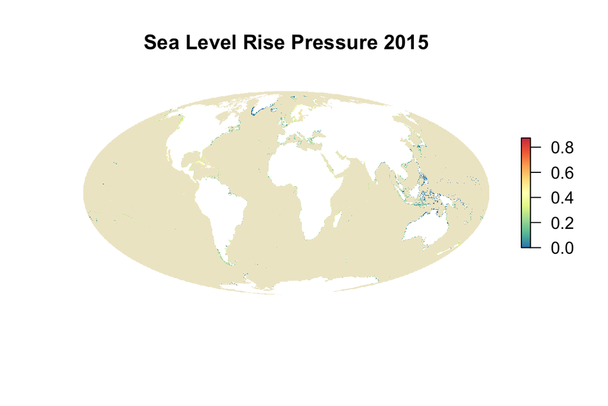

```r
r <- raster(file.path(dir_anx,'prs_slr/v2016/output/slr_2015.tif'))

plot(ocean, col='cornsilk2', axes=F, box=F, main='Sea Level Rise Pressure 2015', legend=F)
plot(r,col=cols,axes=F,box=F,add=T)
```

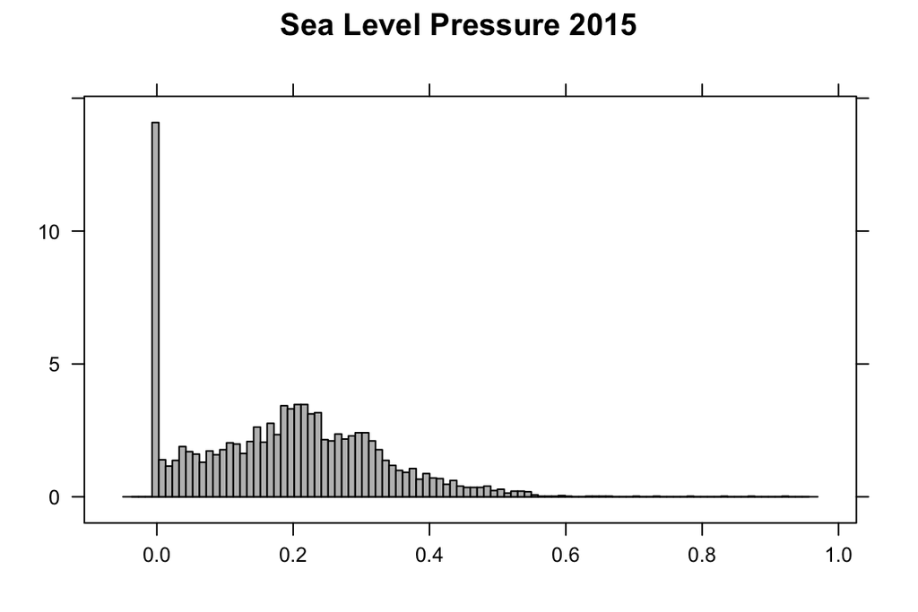

```r
histogram(r, main ='Sea Level Pressure 2015')
```

### Citation information

The altimeter products were produced and distributed by Aviso (http://www.aviso.altimetry.fr/), as part of the Ssalto ground processing segment. [AVISO MSLA heights, monthly means](http://www.aviso.altimetry.fr/en/data/products/sea-surface-height-products/global/msla-mean-climatology.html)